# PSTAT 131 Final Project Predicting Myopia

## Variable importance plot for the best model (overfitted elastic net model)

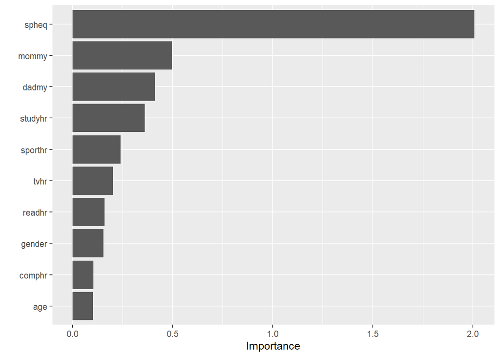

```r
library(vip)
final_fit_up %>% extract_fit_parsnip() %>% vip()
```

```r
# Checks the gender distribution between myopic and non-myopic children
gender_table_num <- table(myopia_data$gender, myopia_data$myopic)
gender_table_num
```

```
##
##           No Yes
##   Male   281  35
##   Female 256  46
```

What stands out to me in the variable importance plot is how important spheq was to predicting myopia compared to the other variables. Visually it seems like spheq is four times more important. But this makes logical sense because spherical equivalent refraction (spheq) is a measure of the eye’s refractive error, and lower spheq values indicate a higher degree of nearsightedness. Spheq is a main indicator of myopia risk, which explains its high importance. The other predictors are more indirect measures of myopia risk, so they have lower importance scores. But to clarify, spheq is not the overall determination of someone having myopia because myopia is a multifactorial condition, meaning it is rarely determined by a single factor (Huang, Zhang, and Zhou 2025).

## Conclusion

Looking back at everything that happened throughout this project, many improvements could have been made. For starters, using oversampling was necessary, but is not the most efficient approach because it results in overfitting. In order to make sure that the model does not overfit, it would have been better to find a larger amount of data with an increased number of naturally occurring myopic children without using oversampling at all or some other method I am unaware of. Furthermore, in the future, different resampling techniques could have been used to address the imbalance of children who did develop myopia, such as tree-based methods (random forest, boosted trees).

## Sources

1. The myopia dataset: https://github.com/bekkabratch/aps-clone/blob/master/data/myopia.rda Hosmer, D. W., Lemeshow, S., & Sturdivant, R. X. (2013). Applied Logistic Regression (3rd ed.). Wiley. Retrieved from https://github.com/bekkabratch/aps-clone
2. Congdon N, Burnett A, Frick K. The impact of uncorrected myopia on individuals and society. Community Eye Health. 2019;32(105):7-8. PMID: 31409943; PMCID: PMC6688418. [https://pmc.ncbi.nlm.nih.gov/articles/PMC6688418/]
3. Huang L, Zhang D, Zhou J. Myopia development: multifactorial interplay, molecular mechanisms and possible strategies. Front Med (Lausanne). 2025 Aug 26;12:1638184. doi: 10.3389/fmed.2025.1638184. PMID: 40933557; PMCID: PMC12417417. [https://pmc.ncbi.nlm.nih.gov/articles/PMC12417417/]
4. Figure 1: What is a spherical equivalent in myopia? (n.d.). https://clearsightcorner.com/articles/what-spherical-equivalent-myopia
5. Figure 2: Meomartino, L., et al. “Ocular Ultrasonographic and Biometric Features of European Brown Hares (Lepus Europaeus).” Anatomia, Histologia, Embryologia, vol. 47, no. 3, 2018, pp. 250-253, https://doi.org/10.1111/ahe.12350.